# WPA #10 – Writing APA style articles with Markdown and Papaja

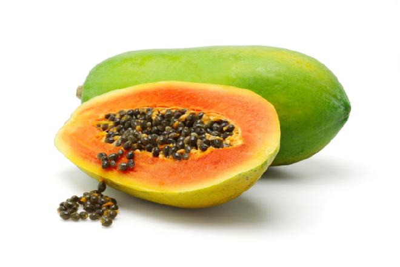

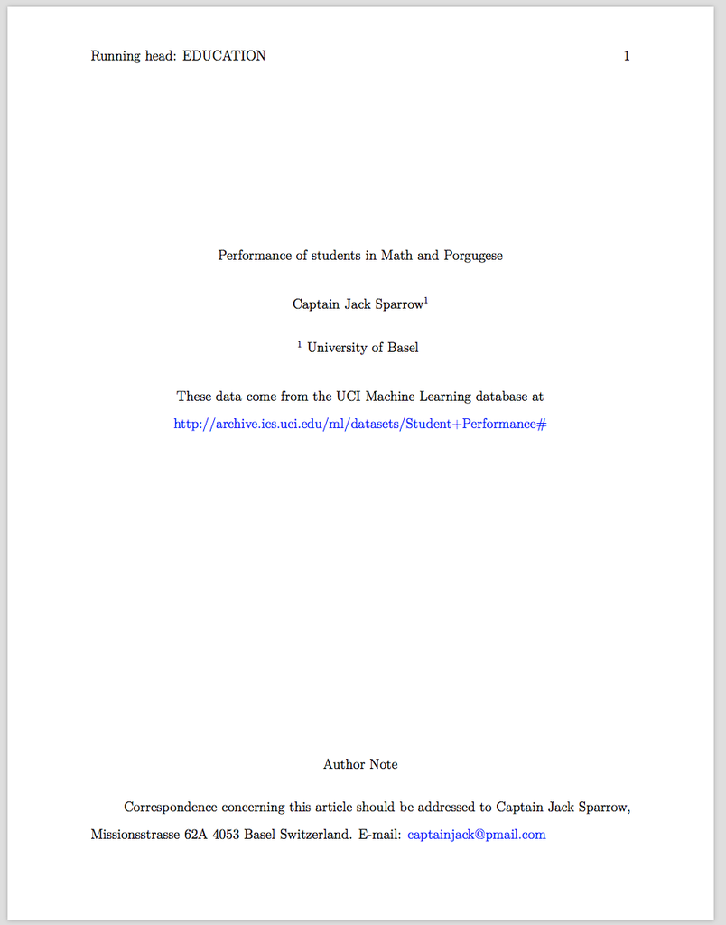

## Readings

This assignment is based on the following readings:

- [Markdown Video](https://www.youtube.com/watch?v=7qTvOZfK6Cw)
- [Markdown Guide](http://www.rpubs.com/YaRrr/markdownbasics)
- [RStudio Lessons](http://rmarkdown.rstudio.com/lesson-1.html)
- [papaja Guide](https://ndphillips.github.io/IntroductionR_Course/readings/papajaguide.html)

## Assignment Goals

- Create the following APA style document (https://github.com/ndphillips/IntroductionR_Course/blob/master/assignments/wpa/studentAPA/studentAPA_comp.pdf?raw=true) using R markdown and the papaja package
- Automatically create APA style statistical conclusions from R objects using `papaja::apa_print()`
- Cite articles using `.bib` files and appropirate bibtex citations.
- Use in-line ‘minichunks’ to incporate R output directly into your text.

## Examples

```r
# Install papaja from github
# install.packages("devtools")   # In order to install packages from github
# devtools::install_github("crsh/papaja", build_vignettes = TRUE)

library(papaja)

# Open a papaja template from the R Studio file menu
# File -- New File -- R Markdown -- From Template -- APA Article (6th edition)

# Knit the document using the Command + Shift + K shortcut (or by clicking the "knit" button at the top of your source editor)

library(yarrr) # To get the pirates dataframe

# ---------------------
# Show APA syle conclusions from a t.test object
# ------------------

# t.test comparing the ages of male and female pirates

sex_age_ttest <- t.test(formula = age ~ sex,
                        data = pirates,
                        subset = sex %in% c("male", "female"))

# Create apa style outputs from sex_age_ttest
sex_age_ttest_apa <- apa_print(sex_age_ttest)

# Show all output types
sex_age_ttest_apa

# Here are the different types of outputs
names(sex_age_ttest_apa)

# Full output
sex_age_ttest_apa$full_result

# $\\Delta M = -4.96$, 95\\% CI $[4.29$, $5.62]$, $t(949.43) = 14.53$, $p < .001$

# ---------------------
# Show APA syle conclusions from an lm (regression) object
# ------------------

# regression comparing tattoos as a function of sex, headband, and age

tattoos_lm <- lm(formula = tattoos ~ sex + headband + age,
                  data = pirates)

# Create apa style outputs from tattoos_lm
tattoos_lm_apa <- apa_print(tattoos_lm)

# Look at all outputs
tattoos_lm_apa

# Full result for age
tattoos_lm_apa$full_result$age

# Here is the full APA style conclusion for age
# $b = 0.02$, 95\\% CI $[-0.02$, $0.05]$, $t(995) = 0.96$, $p = .340$

# ---------------------
# Show APA syle conclusions from an Anova object
# ------------------

# Create anova object from tattoos_lm
# In this example I'm conducting a type II anova using car::Anova
tattoos_aov <- car::Anova(tattoos_lm)

# Get apa style results
tattoos_aov_apa <- apa_print(tattoos_aov)

# Look at all outputs
tattoos_aov_apa

# Full result for sex
tattoos_aov_apa$full_result$sex

# ANOVA table
tattoos_aov_apa$table


# ---------------------
# Show a APA style table of data
# ------------------

# Convert a dataframe to an APA formatted LaTeX table

apa_table(pirates[1:10, c("id", "sex", "age", "tattoos", "tchests")],
          caption = "First few rows of the pirates dataframe")
```

### Install LaTeX and papaja

A. In order to render PDF files, you need to have LaTeX installed. Go to one of the following links and follow the instructions to install LaTeX your computer. The files are quite large (2 gigabytes I think), so on a slow connection it may take a while…

Windows: MikTeX https://miktex.org/ Mac: MacTeX: http://www.tug.org/mactex/

Afer you’ve installed LaTeX, restart your computer (otherwise RStudio won’t know that you’ve installed LaTeX)

B. Once you have installed LaTeX, install the `papaja` package from GitHub using the `install_github()` function from the `devtools` package. If you don’t have the `devtools` package, you’ll need to install that first.

```r
# install.packages("devtools") # Only if you don't have the devtools package yet

devtools::install_github("crsh/papaja",
                         build_vignettes = TRUE) # Install papaja from GitHub
```

### Get started

1. Create a new R project called `studentAPA.RProj`.
2. Navigate to the project directory (the one you just put `studentAPA.RProj` in). Create two new folders `R` and `data` in your project directory.
3. The two data files you ned for this assignment are located at https://raw.githubusercontent.com/ndphillips/IntroductionR_Course/master/assignments/wpa/data/studentmath.txt (the math data) and https://raw.githubusercontent.com/ndphillips/IntroductionR_Course/master/assignments/wpa/data/studentpor.txt (the portugese data), we need to get these files into your data folder. To do this, open a new script. Then run the following code to save the data as text files called `studentmath.txt` and `studentpor.txt` in your data folder:

```r
# Load the two datasets into R

student.math <- read.table("https://raw.githubusercontent.com/ndphillips/IntroductionR_Course/master/assignments/wpa/data/studentmath.txt",
                      sep = "\t",
                      header = TRUE)

student.por <- read.table("https://raw.githubusercontent.com/ndphillips/IntroductionR_Course/master/assignments/wpa/data/studentpor.txt",
                      sep = "\t",
                      header = TRUE)

# Write as tab--delimited text files in the data folder

write.table(student.math,
            file = "data/studentmath.txt",
            sep = "\t")

write.table(student.por,
            file = "data/studentpor.txt",
            sep = "\t")
```

4. Open a new R Markdown document using the papaja template. Do this by clicking File – New File – R Markdown – From Template – APA Article (6th Edition). Save the file in the top level of your working directory (that is, next to the `studentAPA.Rproj`) as `studentAPA.Rmd`.
5. Knit the document to see a simple APA style document! Do this by clicking the Knit button at the top of your source window, or by using the Command + Shift + K shortcut.
6. In a web browser, go to https://raw.githubusercontent.com/ndphillips/IntroductionR_Course/master/assignments/wpa/studentAPA/studentAPA_blank.Rmd. Copy all of the text, and paste it into your `studentAPA.Rmd` file (replace all of the text that was there before). Save the file.
7. Open a new text file by clicking File – New File – Text File. Save the file in the top level of your working directory as `studentAPA.bib`.
8. In a web browser, go to https://raw.githubusercontent.com/ndphillips/IntroductionR_Course/master/assignments/wpa/studentAPA/studentAPA.bib. Copy all of the text, and paste it into your `studentAPA.bib` file. Save the file.

### STOP!!!

By now you should have a file structure on your computer that looks like the following screenshot.

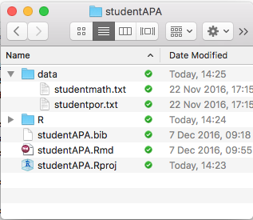

Here is how your RStudio screen should look when you are in the appropriate project. Note that the file structure matches the one on your computer.

[figure not shown]

If you don’t have this folder structure and/or you don’t have the appropriate project open in RStudio, the rest of the document won’t work!

9. Your goal is to create the following APA document (https://github.com/ndphillips/IntroductionR_Course/blob/master/assignments/wpa/studentAPA/studentAPA_comp.pdf?raw=true) by adding elements to the `studentAPA.Rmd` document. In a web browser, go to the link above to download the `studentAPA_comp.pdf` file and see how it looks.

### Adding titles and knitting for the first time

10. In `studentAPA.Rmd`, replace the X values in the main fields at the top of the document (name, paper title, short-title, affiliation) with the appropriate names and titles.
11. Now *Knit* your document to see the current version of the PDF output! You can do this by clicking the “Knit” button at the top of your window or by using the Command + Shift + K shortcut (on Mac).

### Add references to the .bib file

12. Now it’s time to add some references to your `studentAPA.bib` file! You will be referencing three papers in this document. Using scholar.google.com, find the BibTeX references for the following paper(s) and add them to your `studentAPA.bib` file. Make sure to save the file!
- Horwitz, Elaine K., Michael B. Horwitz, and Joann Cope. “Foreign language classroom anxiety.” The modern language journal 70.2 (1986): 125-132.
- Collier, V. P. (1992). A synthesis of studies examining long-term language minority student data on academic achievement. Bilingual Research Journal, 16(1-2), 187-212.
- Abedi, J., & Lord, C. (2001). The language factor in mathematics tests. Applied Measurement in Education, 14(3), 219-234.
13. Now it’s time to cite your new references. I’ve included one citation already in the `studentAPA.Rmd` document in the format @abedi2001language. Now cite the additional papers in your `studentAPA.bib` file by replacing the XXX values with the appropriate citations. **Knit your document to see the result**

### Load data

14. You need to load your data in a separate chunk. I’ve already created a chunk called `setup` with all the code you need. Of course, This code assumes that your data are stored in `studentmath.txt` and `studentpor.txt` in a folder called `data` in your project directory!. **Knit your document to see the result** If you don’t see any errors, then the data should have been correctly loaded!
15. In the Participants section, there are inline code chunks that should indicate the number of participants in each data set. Replace the `1+1` values with `nrow(student.por)` and `nrow(student.math)` to get the number of students in each data set. **Knit your document to see the result**

### Add plots

16. In the Results section, I’ve included a chunk called fig1 that creates Figure 1, a series of histograms. Update the caption to the plot in the chunk options. Then change `eval = FALSE` to `eval = TRUE` to tell Markdown to run the chunk. **Knit your document to see the result**, You should now see the histograms in your document!
17. There is another chunk called `fig2` that plots the correlations between numeric predictors in the math data. Turn on the chunk by setting `eval = TRUE`, update the caption. **Knit your document to see the result**

### Look at different document classes

18. You can render your document in one of three document classes: `doc` (document), `man` (manuscript) and `pub` (publication). At the top of your Markdown file, you’ll see the text `class: man`. Change the class to doc and knit. Then change the class to pub and knit. Look at the new outputs!

### Add statistics

19. Below the Figure 1 chunk, there are some inline chunks that calculate the mean grades for exam 1 and exam 3 of the Portuguese data. Update these chunks with the correct code to calculate the mean G3 scores for the math and portugese datasets. **Knit your document to see the result**
20. The next two chunks create tables of summary statistics for the Math and Portuguese data. Update the captions in these chunks. Then, change `eval = FALSE` to `eval = TRUE` in the chunk options. **Knit your document to see the result** You should now see the tables in your document.
21. The next chunk conducts and saves t-tests for both the math and Portuguese data. The code for the Portuguese test `sex.por.ttest` is already completed, but the code to create a similar test for the math data is missing. Add the code for the math test to create the object `sex.math.ttest`. Then, change `eval = FALSE` to `eval = TRUE` in the chunk options.
22. The next lines use inline code to refer to the results of your t-test objects. Replace the `1+1` values with `papaja::apa_print(sex.por.ttest)$full_result` and `papaja::apa_print(sex.math.ttest)$full_result` **Knit your document to see the result**

## Add new analyses!

23. Add a scatterplot showing the relationship between G1 and G3 for the math data as a new Figure 3. **Knit your document to see the result**
24. In addition to your scatterplot, conduct the appropriate correlation test using `cor.test()` in a separate chunk. Save the result as `math.cor.test`
25. Now report the results of your correlation test in your text. You can easily do this using the `apa_print()` function from `papaja`. **Knit your document to see the result**

## Submit!

- Save and email your `studentAPA.Rmd` file to me at nathaniel.phillips@unibas.ch.
- Go to https://goo.gl/forms/b9dcRH6Ud3pDagOr1 to confirm your assignment submission.